# Processing Data from Raw to Analyzable Form

Chelsea Wood, Gabby Commisso, Connor Whalen

June-August 2025

The purpose of this script is to clean the raw dataset, strip out unneeded fields, sum parasite counts across organs, and generally get the thing into analyzable form. If you ever need things from the raw dataset, they will still be there for you to access! But the processed dataset will have what is needed for most analyses.

First step: load required packages

```r
library(googledrive)
library(skimr)
library(lubridate)
library(tidyverse)
library(reshape2)
library(readxl)
library(readr)
library(dplyr)
library(here)
```

Here’s the workflow that you need to follow for each fish species: 1. List all parasite species detected and figure out which are valid (i.e., lumping some, discarding those that aren’t parasites). 2. Sum across organs within valid parasite species and double counts for those organs that need to be doubled. 3. Create a dataset containing only the data you want (get rid of organ and voucher headers). 4. Melt the dataset so that parasite counts are in one column and parasite names are in another column.

First, bring in all of the meta-data you need to unite with your dissection data

```r
meta_data <- read.csv(here("data", "all_lots_okay_to_dissect.csv"))
meta_data$combo<-paste(meta_data$CI,meta_data$decade,sep="_")
```

# HYBAMA (Hybognathus amarus)

Download most recent file

```r
hybama_today<-read.csv(here("data", "HYBAMA data_2025.07.03.csv"))
length(hybama_today$CatalogNumber)
```

```
## [1] 210
```

Now merge dissection data with meta-data (all.x makes sure that you keep all individual fish from the same lot, even though they have the same catalog number).

```r
hybama_with_metadata<-merge(hybama_today, meta_data, by.x = "CatalogNumber", by.y = "CatalogNumber", all.x = TRUE)
length(hybama_with_metadata$CatalogNumber)
```

```
## [1] 210
```

Let’s make this dataset tidy! Making headers consistent, removing unnecessary columns, etc

```r
hybama_with_metadata <- hybama_with_metadata %>%
  janitor::clean_names()

hybama_with_metadata_tidy <- hybama_with_metadata %>%
  select(-c(73:132))

hybama_with_metadata_tidy <- hybama_with_metadata_tidy %>%
  select (-c(fish_species_1, fish_barcode_1, msb_fish_catalog_number, tissues, island, island_group, verbatim_elevation, lat_long_comments))

view(hybama_with_metadata_tidy)
```

Plot to see where the dissected fish fall.

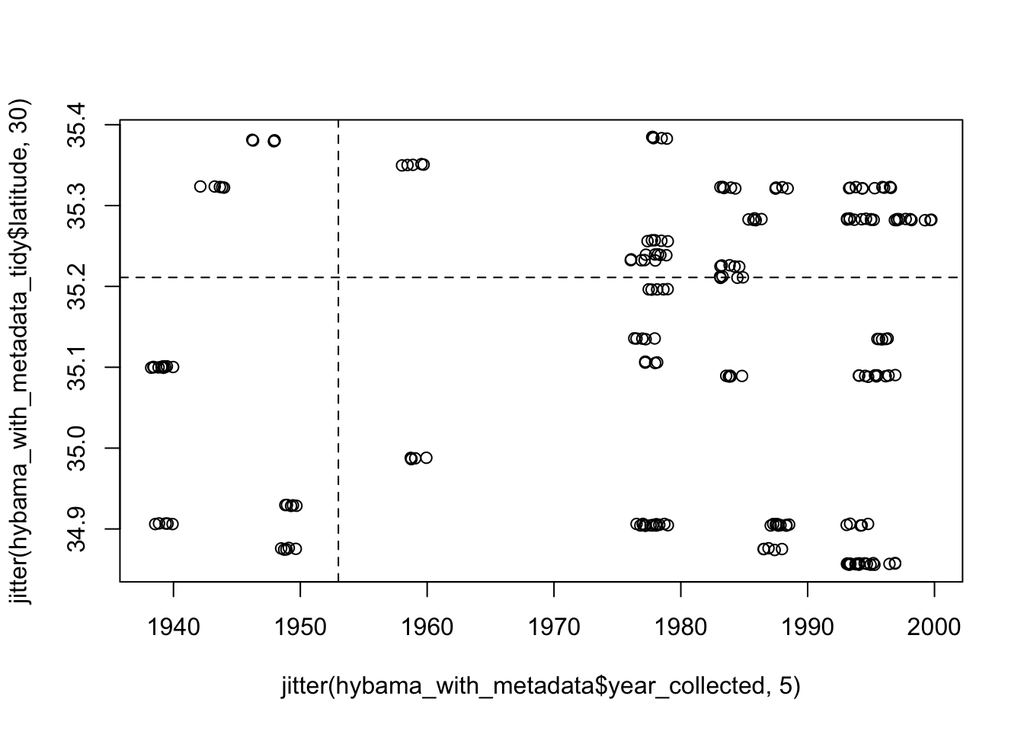

```
## integer(0)
```

```r
plot(jitter(hybama_with_metadata_tidy$latitude,30)~jitter(hybama_with_metadata$year_collected,5))+abline(a = 35.211106, b = 0, lty = 2)+abline(v = 1953, lty = 2)
```

```r
str(hybama_with_metadata_tidy)
```

```
## 'data.frame':    210 obs. of  98 variables:
##  $ catalog_number                       : chr  "MSB:Fish:1129" "MSB:Fish:1129" "MSB:Fish:1129" "MSB:Fish:1129" ...
##  $ individual_id                        : chr  "MSB 1129-5" "MSB 1129-2" "MSB 1129-1" "MSB 1129-4" ...
##  $ fish_species                         : chr  "Hybognathus amarus" "Hybognathus amarus" "Hybognathus amarus" "Hybognathus amarus" ...
##  $ year_fish_collected                  : int  1959 1959 1959 1959 1959 1949 1949 1949 1949 1949 ...
##  $ month_fish_collected                 : int  2 2 2 2 2 10 10 10 10 10 ...
##  $ day_fish_collected                   : int  20 20 20 20 20 29 29 29 29 29 ...
##  $ fish_barcode                         : chr  "JAR8672F" "JAR8674F" "JAR8668F" "JAR8671F" ...
##  $ dissector                            : chr  "JG" "EO" "JG" "EO" ...
##  $ dissection_date                      : chr  "06-20-2025" "06-20-2025" "06-20-2025" "06-20-2025" ...
##  $ completion_date                      : chr  "" "" "" "" ...
##  $ total_length_mm                      : int  40 46 41 41 43 57 61 62 71 68 ...
##  $ standard_length_mm                   : int  32 34 33 31 36 48 49 47 58 54 ...
##  $ weight_mg                            : int  383 697 519 580 659 2022 1811 2068 3286 3151 ...
##  $ examiner                             : chr  "CW" "CLW" "KL" "JG KL" ...
```

[output cut: 84 more lines]

```r
hybama_headers<-ls(hybama_with_metadata_tidy)
hybama_headers<-as.factor(hybama_headers)
```

## Add parasites across organs and double what needs to be doubled.

Notes: - cyst.unk is NOT a parasite - trem_unk_conn and trem_unk_flush are columns of entirely zeros, so were not included in this - myxo.susp was determined to be NOT a parasite

```r
mono.gyro<-2*(hybama_with_metadata_tidy$mono_gyro_pectoralfin)+2*(hybama_with_metadata_tidy$mono_gyro_pelvicfin)+hybama_with_metadata_tidy$mono_gyro_analfin+hybama_with_metadata_tidy$mono_gyro_caudalfin+hybama_with_metadata_tidy$mono_gyro_dorsalfin+2*(hybama_with_metadata_tidy$mono_gyro_gill)+hybama_with_metadata_tidy$mono_gyro_flush

trem.fim <- 2*(hybama_with_metadata_tidy$trem_fim_pectoralfin)+hybama_with_metadata_tidy$trem_fim_caudalfin

cope.lern <- 2*(hybama_with_metadata_tidy$cope_lern_pelvicfin)+hybama_with_metadata_tidy$cope_lern_analfin+hybama_with_metadata_tidy$cope_lern_flush

cope.imler <- hybama_with_metadata_tidy$cope_imler_analfin

trem.meta.unk <- hybama_with_metadata_tidy$trem_meta_unk_caudalfin + hybama_with_metadata_tidy$trem_meta_unk_caudalfin + 2*(hybama_with_metadata_tidy$meta_unk_gill)

trem.diplo <- hybama_with_metadata_tidy$trem_diplo_liver + 2*(hybama_with_metadata_tidy$trem_diplo_eye) + hybama_with_metadata_tidy$trem_diplo_conn + hybama_with_metadata_tidy$trem_diplo_flush

trem.d <- hybama_with_metadata_tidy$trem_d_liver + hybama_with_metadata_tidy$trem_d_conn + hybama_with_metadata_tidy$trem_d_flush

trem.gold <- hybama_with_metadata_tidy$trem_gold_liver + hybama_with_metadata_tidy$trem_gold_conn

trem.em <- hybama_with_metadata_tidy$trem_em_eye

trem.l <- hybama_with_metadata_tidy$trem_l_conn + hybama_with_metadata_tidy$trem_l_flush

trem.b <- hybama_with_metadata_tidy$trem_b_conn + hybama_with_metadata_tidy$trem_b_flush

trem.dlum <- hybama_with_metadata_tidy$trem_dlum_flush

trem.ridge <- hybama_with_metadata_tidy$trem_ridge_flush

nem.cl <- hybama_with_metadata_tidy$nem_cl_int

nem.unk <- hybama_with_metadata_tidy$nema_unk_int

mono.dact <- 2*(hybama_with_metadata_tidy$mono_dact_gill)

myxo.b <- 2*(hybama_with_metadata_tidy$myxo_b_gill)
```

Quickly evaluating relationship between total length and weight to check for any potential abnormalities.

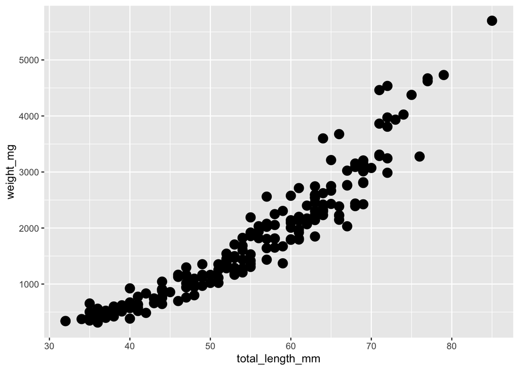

```r
ggplot(hybama_with_metadata_tidy,aes(total_length_mm,weight_mg))+
  geom_point(size=4)
```

Looks good!

## Putting it all together

Put the columns into one dataframe…

```r
hybama_processed_data<-cbind.data.frame(
  hybama_with_metadata_tidy$catalog_number,
  hybama_with_metadata_tidy$year_fish_collected,
  hybama_with_metadata_tidy$month_collected,
  hybama_with_metadata_tidy$day_fish_collected,
  hybama_with_metadata_tidy$individual_id,
  hybama_with_metadata_tidy$fish_barcode,
  hybama_with_metadata_tidy$dissector,
  hybama_with_metadata_tidy$examiner,
  hybama_with_metadata_tidy$dissection_date,
  hybama_with_metadata_tidy$sex,
  hybama_with_metadata_tidy$total_length_mm,
  hybama_with_metadata_tidy$standard_length_mm,
  hybama_with_metadata_tidy$weight_mg,
  hybama_with_metadata_tidy$ci,
  hybama_with_metadata_tidy$combo,
  hybama_with_metadata_tidy$latitude,
  hybama_with_metadata_tidy$longitude,
  cope.imler,
  cope.lern,
  mono.dact,
  mono.gyro,
  myxo.b,
  nem.cl,
  nem.unk,
  trem.b,
  trem.d,
  trem.diplo,
  trem.dlum,
  trem.em,
  trem.fim,
  trem.gold,
  trem.l,
  trem.meta.unk,
  trem.ridge)
```

Name the columns…

```r
colnames(hybama_processed_data)[1]<-"CatalogNumber"
colnames(hybama_processed_data)[2]<-"YearCollected"
colnames(hybama_processed_data)[3]<-"MonthCollected"
colnames(hybama_processed_data)[4]<-"DayCollected"
colnames(hybama_processed_data)[5]<-"IndividualFishID"
colnames(hybama_processed_data)[6] <- "FishBarcode"
colnames(hybama_processed_data)[7]<-"Dissector"
colnames(hybama_processed_data)[8] <- "Examiner"
colnames(hybama_processed_data)[9]<-"DissectionDate"
colnames(hybama_processed_data)[10]<-"Sex"
colnames(hybama_processed_data)[11]<-"TotalLength_mm"
colnames(hybama_processed_data)[12]<-"StandardLength_mm"
colnames(hybama_processed_data)[13]<-"Weight_mg"
colnames(hybama_processed_data)[14]<-"CI"
colnames(hybama_processed_data)[15]<-"combo"
colnames(hybama_processed_data)[16]<-"Latitude"
colnames(hybama_processed_data)[17]<-"Longitude"

view(hybama_processed_data)
```

## Make the dataset analyzable

```r
hybama_processed_data_longer<-melt(hybama_processed_data,id=c(
  "CatalogNumber",
  "YearCollected",
  "MonthCollected",
  "DayCollected",
  "IndividualFishID",
  "FishBarcode",
  "Dissector",
  "Examiner",
  "DissectionDate",
  "Sex",
  "TotalLength_mm",
  "StandardLength_mm",
  "Weight_mg",
  "CI","combo",
  "Latitude",
  "Longitude"))

colnames(hybama_processed_data_longer)[18]<-"psite_spp"
colnames(hybama_processed_data_longer)[19]<-"psite_count"

# Fix data type for weight. Otherwise, it is read as a character and weight is plotted wrong.

hybama_processed_data_longer$Weight_mg <- as.numeric(hybama_processed_data_longer$Weight_mg)
```

## Export both sheets

```r
write.csv(hybama_processed_data_longer, file= "Hybognathus_amarus_processed_machine_readable_2025.07.03.csv")

write.csv(hybama_processed_data, file="Hybognathus_amarus_processed_human_readable_2025.07.03.csv")
```